# Lab #3: Data Visualization

Data Science and Society (Sociology 367)

In this lab, we will practice visualizing data. Edit the Lab #3 markdown file ([link to file](https://github.com/dssoc/dssoc.github.io/raw/master/assignments/Lab_3.Rmd)) for your submission. Remember to change the “author” field above to your name. Send the markdown file (.Rmd) to your TA via direct message on Slack.

The exercises in this lab correspond with *R for Data Science* (Wickham), [chapters 3 and 28](https://r4ds.had.co.nz/data-visualisation.html), and *Data Visualization a Practical Introduction* (Healy), [chapter 1](http://socviz.co/lookatdata.html).

**Optional Resources:**

- [RStudio Cloud intro](https://rstudio.cloud/learn/primers/3)
- [Data Visualization: A Practical Introduction](http://socviz.co/), Kieran Healy. (Princeton: Princeton University Press, 2019)
- [Fundamentals of Data Visualization](https://serialmentor.com/dataviz/)
- [The R Graph Gallery](https://www.r-graph-gallery.com/)
- [Sometimes the y-axis doesn’t start at zero, and it’s fine.](https://flowingdata.com/2015/11/23/sometimes-the-y-axis-doesnt-start-at-zero-and-its-fine/)
- [What would feminist data visualization look like?](https://civic.mit.edu/2015/12/01/feminist-data-visualization/), MIT Civic Media Lab by kanarinka.

### Required Dataset

The data that you will be using for this lab can be downloaded from the course website:

- `artist_meta`: artist_meta.Rdata is a table of Grammy nominee names and some of their metadata.

**Load the datasets:**

```r
library(tidyverse)
load('data/artist_meta.Rdata')
```

### Exercises

**1. Using the `artist_meta` table, create a new factor variable (`is_pop`) that indicates whether the artist is associated with any pop genre (e.g. a genre that has the word “pop” in it). The labels for this factor variable should be ‘pop’ and ‘not pop’.**

```r
artist_meta <- artist_meta %>%
  mutate(popularity=as.numeric(popularity)) %>%
  mutate(is_pop = as.factor(ifelse(grepl('pop', as.character(genre), fixed=TRUE), 'pop', 'not pop')))
```

**2. Using the `artist_meta` table, make a scatterplot of `followers` vs `popularity`.**

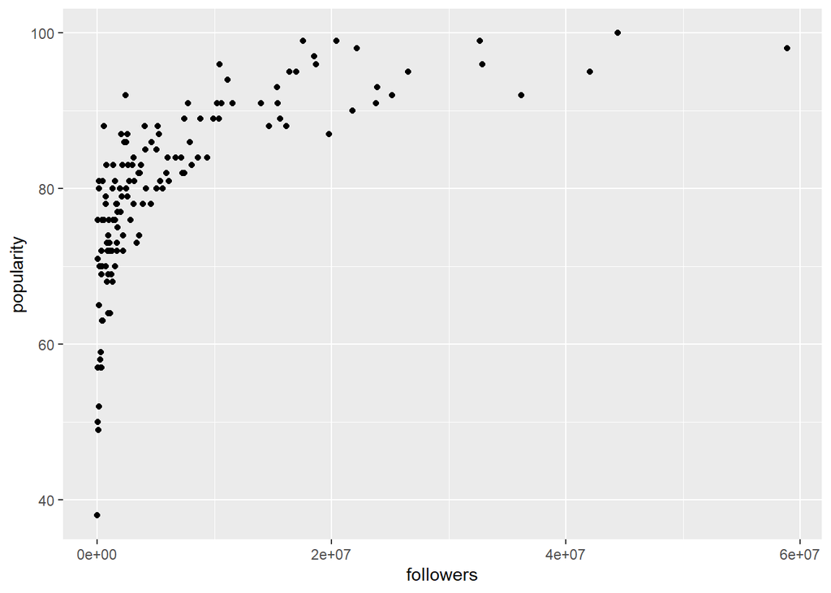

```r
# your answer here
artist_meta %>% ggplot(aes(followers, y=popularity)) +
  geom_point()
```

**3. Change the theme of your scatterplot from Exercise 2, and apply appropriate x- and y-axis labels. Note: for theme information, see 28.6 in *R for Data Science* or 8.3 of *Data Visualization a Practical Introduction*.**

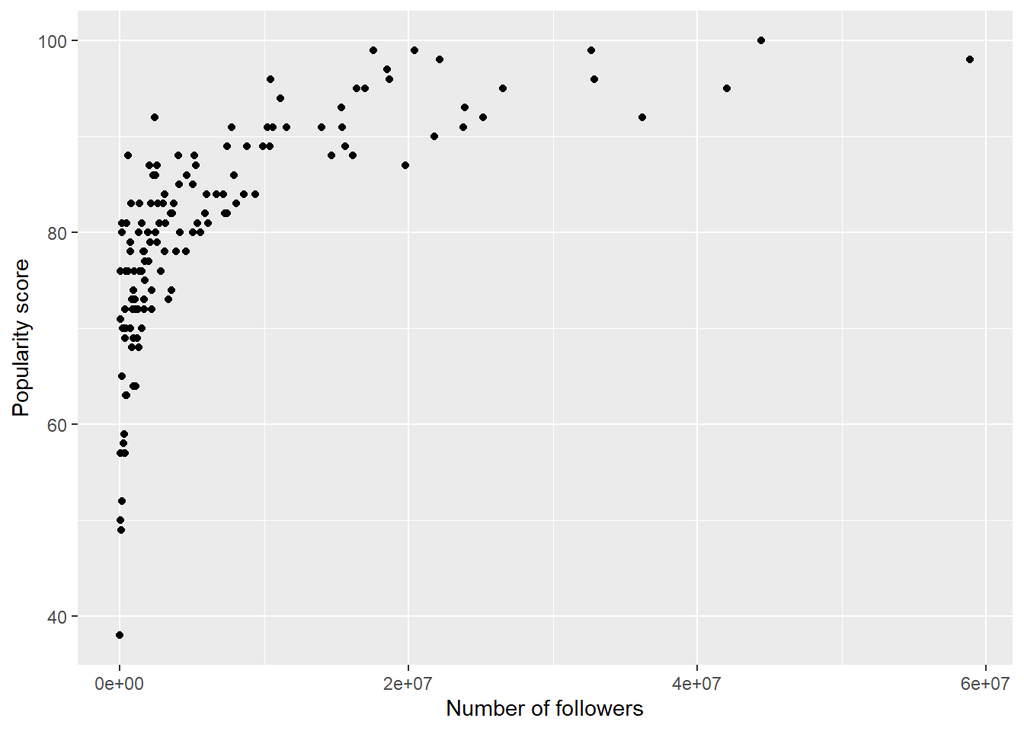

```r
artist_meta %>% ggplot(aes(followers, y=popularity)) +
  geom_point() +
  labs(x= 'Number of followers', y='Popularity score')
```

**4. Now, color your scatter plot points according to whether the artists are associated with a pop genre.**